# Literate Programming with R and RStudio

## Learning Objectives

You will learn:

- What literate programming is
- Why literate programming matters
- What tools are available for literate programming
- How to use R and RStudio for literate programming
- What kinds of documents R Markdown supports
- The basics of formatting documents with R Markdown
- The basics of using *knitr* to render R Markdown documents
- How to share or publish R Markdown and rendered documents

## Literate Programming

Literate Programming is:

- Interspersing explanatory text with code
  - to make a report that is executable
    - to automate report production

## Reproducibility

For the purpose of this discussion, let's define:

- *Replicate*: to repeat a study (with new samples and data)
- *Preproduce*: to regenerate the results of an analysis (with the same data)

Our studies may be difficult to fully *replicate* … but our analysis should always be *reproducible*.

Or in other words:

We should always be able to go from raw data to final results at any time … *and always get the same results* from the same data and the same analysis*.

`*` Even if you are doing modeling with randomly-generated values, you can set the *seed* to produce the same values each time you run the analysis.

## Literate Programming

In the light of reproducibility, Literate Programming is:

- Interspersing explanatory text with code
  - to make a report that is executable
    - to automate report production
      - and to improve reproducibility
        - by allowing the recipient to re-render the report
          - to verify the results (plots and figures)
            - are produced from the embedded code

## Literate Programming Tools

There are two main platforms for literate programming:

- *Python*: Jupyter Notebook
- *R*: R Markdown and *knitr*

Both platforms can be used with other programming languages or a mix of them.

## Jupyter Notebook

Jupyter Notebook runs in a web browser and embeds results as you type commands. We will not be using Jupyter Notebook in today's module.

[figure not shown]

A Jupyter Notebook rendered as a webpage. Image by: [opensource.com](https://opensource.com/education/15/11/project-jupyter-science-notebooks)

## R Markdown and *knitr*

To use R Markdown and *knitr* for Literate Programming, all you need is a text editor, R, and a few packages such as *knitr*. These tools are well integrated into RStudio.

- R Markdown: The text notation you use for formatting, based on Markdown
- *knitr*: A package by Yihui Xie used to render R Markdown documents

[figure not shown]

Markdown document rendered as a webpage. Image by: [RStudio Blog](https://blog.rstudio.org/2014/06/)

## Installing R Markdown and *knitr*

### R Packages

You need the R packages *htmltools*, *rmarkdown* and *knitr*.

```r
install.packages(c("htmltools", "rmarkdown", "knitr"), dependencies = TRUE)
```

### `pdflatex`: PDF Conversion Utility

To generate PDFs, you will need `pdflatex` which comes with…

*Windows*: [Basic MiKTeX](http://miktex.org/howto/install-miktex) – *OS X (macOS)*: [Basic MacTeX](http://www.tug.org/mactex/morepackages.html)

Tip: Restart RStudio after these utilities are installed.

*Or on any system*: [TinyTeX](https://yihui.name/tinytex/)

```r
install.packages("tinytex"))
tinytex::install_tinytex()
```

## R Markdown Syntax

[R Markdown](http://R%20Markdown.rstudio.com/) is a "wiki" syntax based on [Markdown](https://daringfireball.net/projects/markdown/). Here is an example:

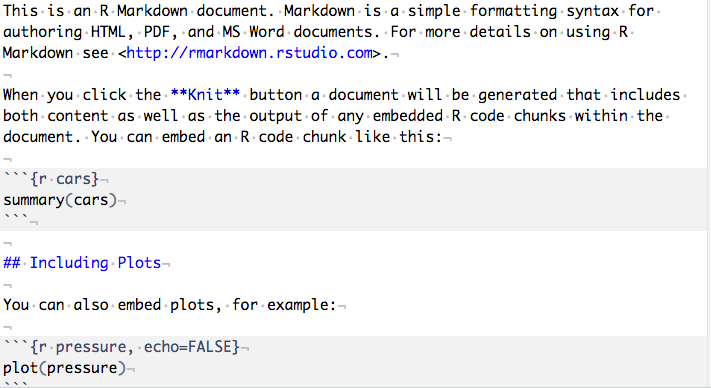

## R Markdown Cheatsheet

[figure not shown]

[R Markdown cheatsheet](https://www.rstudio.com/wp-content/uploads/2016/03/rmarkdown-cheatsheet-2.0.pdf)

## *knitr*

The R package which renders the R Markdown document is *knitr*. It uses other packages and utilities as needed to produce different document formats.

In RStudio, you would nomally run *knitr* using the *Knit HTML* button.

If your document has been configured in R Markdown to generate a PDF document, the the button will show as *Knit PDF*.

So, the appearance of the button changes depending on the document type.

You can also the *File* -> *Knit Document* or *File* -> *Compile Notebook* menu options.

## Sharing and Publishing

You can share your R Markdown source document, along with any data, images, and other related files on an online repository, such as GitHub.

[figure not shown]

[bootcamp repository](https://github.com/brianhigh/computing_bootcamp)

## Sharing and Publishing

You may also use the *Publish* button or *File* -> *Publish…* menu choice. This will send the rendered document to the RPubs website, run by RStudio.

[figure not shown]

[NDBC document](http://rpubs.com/brianhigh/210190)

## Example: Weather Data Plot

Given this script: ndbc_plot.R, convert to R Markdown and render in various formats (HTML, PDF, Markdown, and MS-Word). Is this "reproducible"? Why or why not?

One version of this script, as rendered from R Markdown, is published on [RPubs](http://rpubs.com/brianhigh/210190).

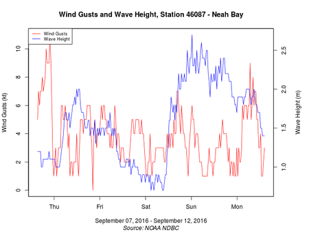

## Exercise #1: Zika Cases US Map

Convert zika.R (most recent CDC data) or zika.R (CDC data as of 2016-08-31) to R Markdown and render as HTML and PDF. Which is more "reproducible"?

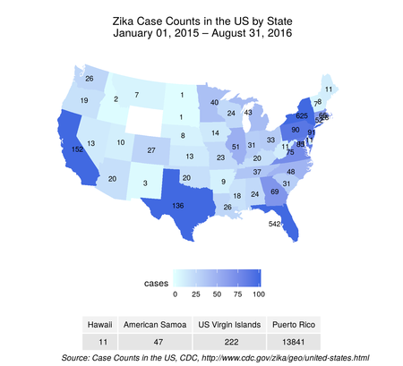

## Exercise #2: World Malaria Prevalence

Convert malaria.R to R Markdown and render as HTML and PDF. You may choose to use only a few sections of the analysis (like "prevalence by subregion") to save time.

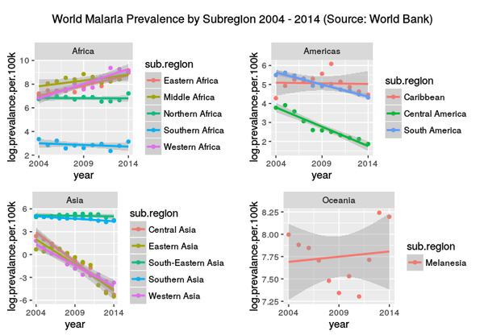

[output not shown]